# dissertation2

## Intro - The Partitioned Array Data Structure Library and LineDB

### Introduction

The partitioned array and now, the LineDB library aims to solve the problem of large arrays in high level settings. That is, they don’t work. Memory limitations and the limitations of hardware prevent an array database from storing, say, 1,000,000 entries.

The partitioned array/manager is designed to only look at a specific “file context" (and,”database” in ‘LineDB’), and partitions within that given ‘file context’.

While ‘LineDB’ resolves all problems of managing partitioned array file objects, it is still necessary to at least understand how to start a new object, allocate it, save all files to disk, get, and add elements to the object.

The ‘partitioned array library’ at its core, is capable of storing data created in the ‘partitioned array’ libraries to disk on function call. I found this very useful for anything, because now it is easy to manage an “`Array-Of-Hashes'`” data structure. The file format it is stored to is the ‘JSON’ file format and object specification (‘javascript object notation’), and the partitioned array data structure uses the Ruby programming language, with ports for other languages such as ‘Rust’ and ‘Python’ on its way thanks to ongoing AI advancements.

#### Class Heirarchy Tree

The class heirarchy is as follows, starting from the PartitionedArray and the class heirarchy has a decomposition, going down from the most abstracted to the Managed/Partitioned Array. The Managed Partitioned array inherits from the Partitioned Array, and nothing else does. Variables are passed down the classes, even when starting from LineDB

The class Heirarchy is as follows:

```ruby
 PAD = PartitionedArrayDatabase
 FCMPAM = FileContextPartitionedArrayManager
 FCMPA = FileContextPartitionedArray
 MPA = ManagedPartitionedArray
 PA = PartitionedArray

LineDB.PAD.FCMPAM.FCMPA.(ManagedPartitionedArray > PartitionedArray) # so-called "class heirarchy [decomposition]"; ManagedPartitionedArray
# inherits from PartitionedArray and thus PartitionedArray needs not be used over MPA
```

Which is simply designed to give an overview of the approximate number of method nested calls one would have to do to use the ManagedPartitionedArray. Ultimately, every part of the data structure library uses the ManagedPartitionedArray at the base level, and, even, according to the class heirarchy.

## Data Structures Used

- Arrays
- Associated Arrays/Hashes
- JSON/filename.json (JavaScript Object Notation)

## The Fundamental Data Structures: “`Managed' Partitioned Arrays`”, …)

#### A “Partitioned Array” Data Structure (Synopsis)

The partitioned array’s fundamental characteristic is that all elements are placed into an invisible partition, meaning if you were to take out the data structure ( ‘`@data_arr`’ ), it would be a linear type of an array with a hash/associated array in each indice, that is predictable and can be used apart from the classes used to create them

Fundamental Equation (non-algebraic) Which Defines A Partitioned Array’s “Get” Function:

```ruby
# Special case; composing the array_id

if db_index.zero?
    array_id = relative_id - db_index * @partition_amount_and_offset
else
    array_id = (relative_id - db_index * @partition_amount_and_offset) - 1
end
```

A partitioned array is defined as a data structure which has “partitioned elements” within what should be a ‘regular array’

The data structure used for every element in the array is a Ruby Hash, or otherwise known as an Associative Array

Example of how a ‘partitioned array’ is structured, where each integer stands for an element index in the partitioned array (where a hash/associated array would be in place anyways):

‘figure 69 (partitioned array structure):’

`'[[0, 1, 2], [3, 4], ..., [n, n+1]]`’

*‘Caveat’*: The first partition (‘`[0,1,2]`’ always contains the 0th element otherwise known as ‘0’ )

However, as a note: The partitioned array algorithm is currently coded in a way that it does not actually use subarrays; the algorithm takes responsibility for all aspects of the data structure (partitions, ranges, etc), so an array when defined by ‘fig 69’, would look slightly different, it would look like...

‘`[0, 1, 2, 3, 4, n, n+1, n+2, ..., n+k]`’

Note: The basic idea is you can store the array itself onto disk and “switch off” certain partitions, thus allowing for Ruby’s Garbage collector to take hold.

‘A partitioned array data structure works with JSON for disk storage, and a pure JSON parser is in progress. With two constants, the algorithm creates a data structure and allocates empty associative array elements and understands the structure of the partitions.’

The main purpose was I needed a way to divide an array into subelements, so that in gamedev I can flip on and off portions of the array in question to save on memory.

The data structure overall is an ‘Array-Of-Hashes’.

For more information on the instance methods of the Partitioned Array, see the README

##### Managed Partitioned Array (Partitioned Array Specifications)

This will talk about the Partitioned Array and its suggested counterpart superset, the ‘ManagedPartitionedArray (lib/managed_partitioned_array.rb)’

In a great sense, the Partitioned Array could be considered the superset or fundamental basis of the data structure, going on out from the ‘Partitioned Array’

The Managed Partitioned Array adds a “file context” (database) to the partitioned array. It allows for the switching to a new “file context” on command.

This will do one thing: It will allow the programmer to switch to the new file context, in turn freeing up the memory of the previous partition or whichever partition the Managed Partitioned Array was referencing. That is, it is a change of data structure “pointers” using “Value Objects” as the method of doing so (however, the LineDB database library fixes that)

A snippet of the table of constants (suggested variables that will be automatically used if you don’t specify in ‘object.new’)

```ruby
# DB_SIZE > PARTITION_AMOUNT

DB_SIZE = 20 # Caveat: The DB_SIZE is the total # of partitions,
# but you subtract it by one since the first partition is 0, in code.
# that is, it is from 0 to DB_SIZE-1, but DB_SIZE is then the max allocated DB size
DB_MAX_CAPACITY = "data_arr_size"
DB_PARTITION_AMOUNT = 9
DB_PARTITION_OFFSET = 1
DB_PARTITION_ADDITION_AMOUNT = 5
DB_NAME = "fcmpa_db"
DB_PATH = "./DB/FCMPA_DB"
DB_HAS_CAPACITY = false
DB_DYNAMICALLY_ALLOCATES = true
DB_ENDLESS_ADD = true
DB_PARTITION_ARCHIVE_ID = 0

# table of constants are used by default; check managed_partitioned_array.rb for usable constants, and the constants stated above
mpa = mpa.new
# Switching to a new "file context" (db)
mpa = mpa.archive_and_new_db!
# Load a specific file context location (integer)
mpa.load_archive_no_auto_allocate!(file_context_location)
# load a given partition (partition_archive_id: Integer)
mpa = mpa.load_from_archive!(partition_archive_id: @max_partition_archive_id)
 # Depends on the MPA variables, but will check to see if, the array is at capacity given
 # that has_capacity is set
mpa.at_capacity?
# add a partition to the database; works with blocks:
mpa.add(return_added_element_id: true, &block)
mpa.add do|hash|
    hash["key1"] = "value1"
    #..
  end
  # see PartitionedArray; returns a hash with additional data if set to true,
  # and the id is the array element id
  mpa.get(id, hash: false)
  # in PA class, its load_all_from_files!
  mpa.load_everything_from_files!
# in PA class, its save_all_to_files!
  mpa.save_everything_to_files!
# an example of a low level variable
  mpa.increment_max_partition_archive_id!
```

In order to use a ManagedPartitionedArray, you need to set a base directory and a few variable constants to set the database size and partitions (but they have default fallback values depending upon which library you focus on, as seen in the table of class inheritance constants)

###### Never Ending Array Adds

```ruby
mpa = ManagedPartitionedArray.new(endless_add: true, has_capacity: false, dynamically_allocates: true)
mpa.at_capacity? # has no use here
```

###### Finite Length Arrays

```ruby
mpa = ManagedPartitionedArray(max_capacity: "data_arr_size" (or some Integer), dynamically_allocates: false)
```

‘use `mpa.at_capacity?`’ to detect when the array is full

- where `max_capacity` is the max number of array elements in a given `partitioned array`

###### Dynamic Allocation

```ruby
mpa = ManagedPartitionedArray.new(dynamically_allocates: true)
```

```ruby
##### Array split by file partitions (file contexts)

mpa = ManagedPartitionedArray.new(max_capacity: data_arr_size, db_size: DB_SIZE,
partition_amount_and_offset: PARTITION_AMOUNT + OFFSET,
db_path: "./db/sl", db_name: 'sl_slice')

# Where 'max_capacity' could be the max '@data_arr' size,
# or a defined integer.

# 'db_path' is the given folder that the database will
# reside in  'db_name' is the database's name

# Check if 'mpa.at_capacity?' to figure out if the MPA
# is at capacity (it returns true if at capacity)
# if it returns true, you can create a new file context:

mpa = mpa.archive_and_new_db! # switch to a new file context (db)
```

###### Switching and allocating to a new file partition

```ruby
mpa = ManagedPartitionedArray.new(max_capacity: "data_arr_size",
db_size: DB_SIZE, partition_amount_and_offset: PARTITION_AMOUNT + OFFSET,
db_path: "./db/sl", db_name: 'sl_slice')
mpa = mpa.archive_and_new_db!
mpa.save_everything_to_files!
```

In the end if you need to load a new partitioned array, just specify it at the same given location and call ‘mpa = mpa.new’. This assumes that you are using the default constants, and if you want to do it explicitly, use ‘mpa = mpa.load_from_archive!’ and it will load from where it left off the last time the program was open

##### File Context Partitioned Array

This is an abstraction layer … It sets up the foundation for a database of partitioned arrays, but that is fully implemented as an abstraction in LineDB.

##### File Context Partitioned Array Manager

The file context partitioned array manager creates the database system for the partitioned array, but all it does is create Managed Partitioned Arrays to create a database manager system for LineDB, which will be explained in LineDB below...

##### Line Database (LineDB) - The core library of the Partitioned Array

The Line Database is an abstraction layer class for the File Context Partitioned Array Manager (and the underlying databases), and the general uses of the partitioned array database will be covered

## Examples & LineDB/MPA Diagram

### Terse Algorithm Example

A terse example of the partitioned array’s get function, in which the rest of the algorithm uses as a `basis`, especially the equation. (in https://github.com/ZeroPivot/partitioned_array/tree/master/examples )

The algorithm uses Ranges (inequalities in a sense, ex: `0..25`) and I called the algorithm the Ranged Binary Search (`bsearch` is the `binary search` in arrays), thus the algorithm’s search time for getting a given entry (extra overhead to, say, getting an array element straight from the array) is `O(lg n)`.

The weirdness derived from the equation is that in the 0th partition, there is always one extra element I call the 0th element, which means that in an ordinary partitioned array, there is always n+1 elements, where n alone is what the partitioned array would be in terms of its full element count.

What has been stated before, is that the partitioned array is separated by partitions. This is true; the partitioned array when saving to disk saves it in variable chunks, and the range_arr dictates what partition one is looking at. This also means that you can `load individual partitions of a partitioned array straight from disk`, and you also do not need to load every partition at the same time. Algorithmically speaking, the Managed Partitioned Array loads into the current file context. An example of how the partitioned array data structure looks in its abstracted class the LineDB will be placed below.

In the code below, `rel_arr` and `range_arr` maintains the database’s structure, with `rel_arr` being the total number of elements in the partitioned array, and range_arr needed for the binary search in general. `range_arr`, is the number of partitions set to the partitioned array. In the case of `[0..10, 11..21, 22..32]`, for example, there are `3 partitions`.

array_id’s final value would be the one to fit into data_arr to get the associated array data

```ruby
# source: https://github.com/ZeroPivot/partitioned_array/blob/master/examples/range_bs_example.rb

# Ranged binary search, for use in CGMFS
# array_id = relative_id - db_num * (PARTITION_AMOUNT + 1)

# When checking and adding, see if the index searched for in question
PARTITION_AMOUNT = 10
OFFSET = 1

# when starting out with the database project itself, check to see if the requested id is a member of something like rel_arr
rel_arr = [0, 1, 2, 3, 4, 5, 6, 7, 8, 9, 10, 11, 12, 13, 14, 15, 16, 17, 18, 19, 20, 21, 22, 23, 24, 25, 26, 27, 28, 29, 30, 31, 32]

range_arr = [0..10, 11..21, 22..32] # in the field, the range array will have to be split according to the array, and the max id needs to match the last range
puts range_arr
def range_db_get(range_arr, db_num)
  range_arr[db_num]
end

db_index = nil
relative_id = nil
puts range_arr
range_arr.each_with_index do |range, index|
  relative_id = range.bsearch { |element| rel_arr[element] >= 33 }

  if relative_id
    db_index = index
    # we check to see if the relative id in the rel_arr matches the range
    if range_db_get(range_arr, db_index).member? rel_arr[relative_id]
      break # If so, then break out of this iteration
    end
  else
    # If relative_id is nil, we don't have an entry at that location (aside from mismatching numbers)
    db_index = nil
    relative_id = nil
  end
end

if relative_id
  array_id = relative_id - db_index * (PARTITION_AMOUNT + OFFSET)
end

# relative id is nil if no element was found
p "DB number id (db_index): #{db_index}" if relative_id
p "The array database resides in (array_id): #{array_id}" if relative_id
p "The array resulting value is (relative_id): #{relative_id}" if relative_id

unless relative_id
  puts 'The value could not be found'
end

# the implemented
```

#### LineDB Example

```ruby
b = LineDB.new(label_integer: true, label_ranges: true)
b["test"].pad.new_table!(database_table: "test_table", database_name: "test_database")

2000.times   do |i|
b["test"].pad["test_database", "test_table"].add do |hash|
  hash[:name] = "name#{i}"
  hash[:age] = i

end
end
```

`b["test"].PAD["test_database", "test_table"][0..25]`

In this example, b calls the existing “test” database, then calls its partitioned array database, and the test table, which is a notation I added to the partitioned_array_database source code. Upon calling the Partitioned Array Database (PAD), we get the entries in the Database from 0 upto 25

Another example of Class Encapculation and Inheritance Decomposition:

```ruby
# in: partitioned_array/decomposition.rb

require_relative   "lib/line_db"

ldb = LineDB.new
p   ldb.class   # => LineDB
zero = ldb["test"] # PartitionedArrayDatabase
p   zero.class   # => PartitionedArrayDatabase
b = ldb.db("test").pad
p   b.class   # => FileContextPartitionedArrayManager
p   b.man_db.class   \# => FileContextManagedPartitionedArray
c = b.man_db
p c.fcmpa_active_databases["_DATABASE_LIST_INDEX"].class   \# =\> ManagedPartitionedArray


LineDatabase = LineDB
PAD = PartitionedArrayDatabase
FCMPAM = FileContextManagedPartitionedArrayManager
MPA = ManagedPartitionedArray
PA = PartitionedArray
```

[figure not shown]

Visual Of The Data Structure

A visual is shown of the underlying data structure and use of the LineDB. “test” is the given database.

- Using the LineDB.

  The default searchup that LineDB seeks is a ‘db’ folder.

  `require_relative "lib/line_db"`

### Quick note on getting LineDB working

Using `git`, do a git clone in the command line/terminal:

`git clone https://github.com/ZeroPivot/partitioned_array.git`

(Or download the release package on the Partitioned Array’s Github Page, named LineDB)

Into any given folder that you want.

Then,

Create a folder named `'db'`, and place in it a `db_list.txt`with line separated database name of arbitrary choice.

`require_relative "lib/line_db"` or the location of the partitioned array library (lib) folder

There exists methods that add or remove databases (from db_list.txt)

### Some Visuals Of The Data Structure (LineDB)

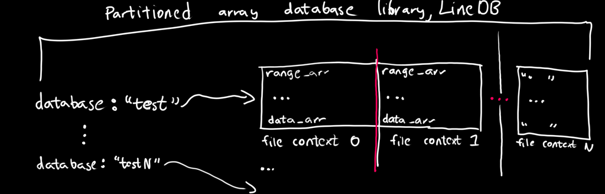

LineDB Structure

## Ending statement

The partitioned array is recent, and after a year’s worth of work I’m finally understanding what I created, which was derived from a single equation and turned into an algorithm

If one needs extra clarification, e-mail me at EigenFruit@gmail.com, I have a lot of free time and I would be more than willing to assist. In the end the partitioned array is there to create a data structure in a specific way, and its aim was towards game engine development, but I also am using and testing it in a web development environment.

## Contact & Links

- Name: Duke Grable
- Twitter: ‘SimulWolf’ - https://twitter.com/SimulWolf
- E-mail: City.Wolf.In.Rural@gmail.com
- Partitioned Array Algorithms Source Code: https://github.com/ZeroPivot/partitioned_array (contained in `lib` root folder; every class can work on its own, but LineDB simplifies it)
- README: https://github.com/ZeroPivot/partitioned_array#readme
- YARD Documentation: https://midscore.io/partitioned_array_library/doc/index.html